# Fossil Mean vs modern Taxonomy v.2

Robin von Allmen

18 3 2021

## Preparing Data

First we read in the Data of our 10 samples of our Fossil to create a procrustes fit, from which we then create the “Mean Shape” of our specimen to rule out the effects of perspective on the picture from the CT-Scan.

```r
landmark = readland.tps("FOSSIL_R.TPS",specID = "ID", readcurves = T, warnmsg = TRUE)


##      define Semilandmarks, first LM is the start, last one the end (those are both
##      fixed landmarks, in between are the semilandmarks):
sliders = define.sliders(c(15,22:29,16))

##      procrustes fit - "superimposition" - rotates and scales the landmarks to their closest distance,
##      minimizing the shape and size difference:
proD<-gpagen(landmark, surfaces = NULL, curves = sliders,
             PrinAxes = FALSE, max.iter = NULL, ProcD = T, Proj = TRUE,
             print.progress = TRUE)
```

## PCA Analysis

We can look at the PCA for a second, however eventhough these are Data of the very same data, the variation may be huge, since the variation will be scaled depending on how equal they are. So if we would put all the other Data in this plot as well these points would relatively be closer together.

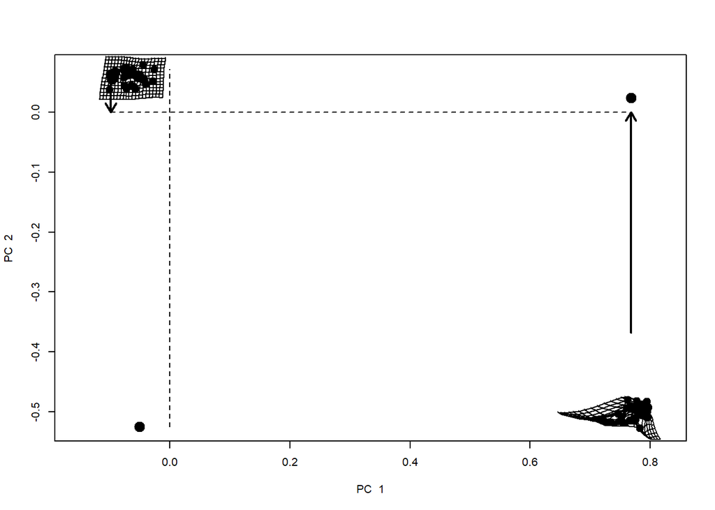

```r
PCA1 <-plotTangentSpace(proD$coords)
```

```r
dev.off()
```

```r
plot3d(PCA1$pc.scores[,1:3], col = "cyan", size = 9)
```

[interactive chart not shown]

Now we create our Mean shape for our specimen and load the other data which we append our fossil later.

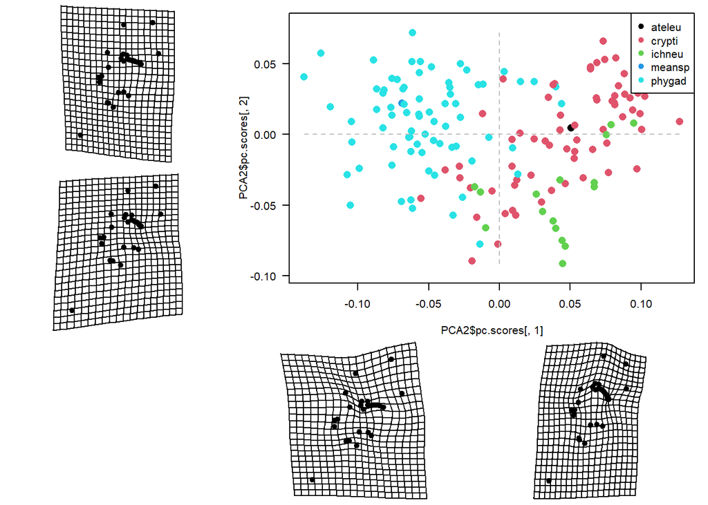

```r
#consesus Data from the proD contains the mean points for the procrustes fit of the fossil versions.
meanfossil <- array(proD$consensus,dim= c(29,2,1))
#change the name of the 3rd row so that we can later label our fossil specifically.
dimnames(meanfossil)[[3]] <- "fossil_meansp_g.JPG"

landmark = readland.tps("DATA_MODERN_TAX.TPS",specID = "ID", readcurves = T, warnmsg = TRUE)
landmarkIchneu = readland.tps("ICHNEUMONINAE.TPS",specID = "ID", readcurves = T, warnmsg = TRUE)
landmarkphygad = readland.tps("DATASET_PHYGAD.TPS",specID = "ID", readcurves = T, warnmsg = TRUE)
landmarkphygad1 = readland.tps("PHYGAD2.TPS",specID = "ID", readcurves = T, warnmsg = TRUE)
landmarkphygad2 = readland.tps("PHYGAD3.TPS",specID = "ID", readcurves = T, warnmsg = TRUE)
landmark <- Abind(landmark,meanfossil,landmarkIchneu, landmarkphygad, landmarkphygad1, landmarkphygad2)

species = as.factor( substr( dimnames(landmark)[[3]], 1, 6))
subfam = as.factor( substr( dimnames(landmark)[[3]], 8, 13))
areolet = as.factor( substr( dimnames(landmark)[[3]], 15, 15))


##      define Semilandmarks, first LM is the start, last one the end (those are both
##      fixed landmarks, in between are the semilandmarks):
sliders = define.sliders(c(15,22:29,16))

##      procrustes fit - "superimposition" - rotates and scales the landmarks to their closest distance,
##      minimizing the shape and size difference:
proD<-gpagen(landmark, surfaces = NULL, curves = sliders,
             PrinAxes = FALSE, max.iter = NULL, ProcD = T, Proj = TRUE,
             print.progress = TRUE)

PCA2 <-plotTangentSpace(proD$coords, groups=subfam, legend=T)
```

With our meanshape we now get much closer into the family of phygodeuontinae as with our original asset. However this is not only due to our approach of creating a mean for the coordinates, but also because we realized that in our initial fossil data the landmark number 1 was misplaced.

## Clustering in new Taxonomy and Dendrogramm

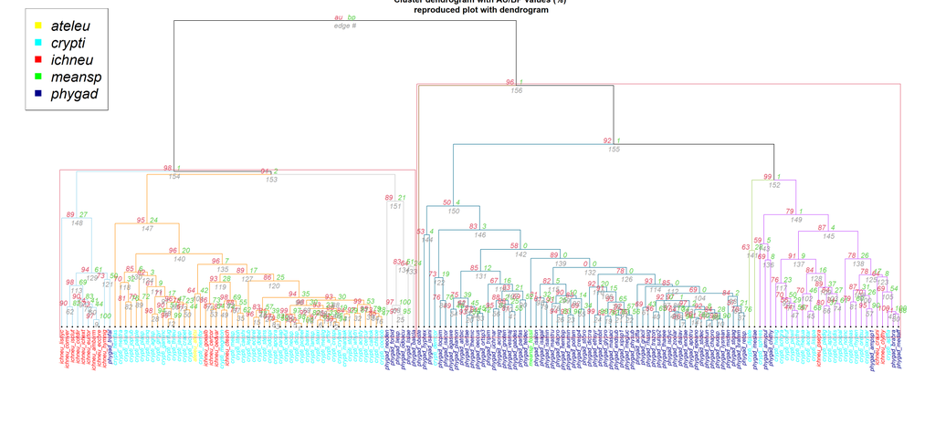

```r
require("dendextend") ## needs a dendrogram


# Create a vector of colors, darkgreen if am is 0, green if 1.

par(mar=c(10,3,1,0), cex = 1, font= 3)

library(pvclust)
result <- pvclust(scale(Proc_dist), method.dist="cor", method.hclust="average", nboot=1000)

dend <- as.dendrogram(result)
Label <- dend%>%labels
my_colors1 = matrix( NA, dim(Proc_dist))
for(i in 1:length(row.names(Proc_dist))){
my_colors1[i] <- switch(substr(Label[i],1,6), "crypti" = "cyan", "ateleu" = "yellow", "meansp" = "green", "phygad" = "darkblue", "ichneu" = "red")
}

# with a dendrogram of pvrect
result %>% as.dendrogram %>%
  set("labels_color", value = my_colors1)%>%
  set("branches_k_color", value = c("skyblue", "darkorange", "grey","darkorange4","deepskyblue4",
                                    "darkolivegreen3","darkorchid1"),k =7) %>%
  set("labels_cex", 0.8)  %>%
  set("leaves_pch", 19)  %>%
  set("nodes_cex", 0.4) %>%

   plot(main = "Cluster dendrogram with AU/BP values (%)\n reproduced plot with dendrogram", axes = FALSE)

result %>% text
result %>% pvrect(alpha=0.95)


legend("topleft", legend=levels(subfam), col= c("yellow", "cyan", "red", "green", "darkblue"), pch=15, cex = 2)
```